# Stat 202: Lecture 8 (covers pp. 112-115)

### Two-way probability table

> 20% chance of experiencing nausea (N), 50% chance of decreased sexual drive (D), and a 15% of both.

Figure out the rest:

```r
      |  D   | not D | Total
------|------|-------|------
N     | 0.15 |       |  0.20
------|------|-------|------
not N |      |       |  0.80
------|------|-------|------
Total | 0.50 | 0.50  |  1
```

### Two-way probability table

> 20% chance of experiencing nausea (N), 50% chance of decreased sexual drive (D), and a 15% of both.

Figure out the rest:

```r
      |  D   | not D | Total
------|------|-------|------
N     | 0.15 | 0.05  |  0.20
------|------|-------|------
not N | 0.35 | 0.45  |  0.80
------|------|-------|------
Total | 0.50 | 0.50  |  1
```

### Plain-text Venn Diagram

**Venn Diagram**

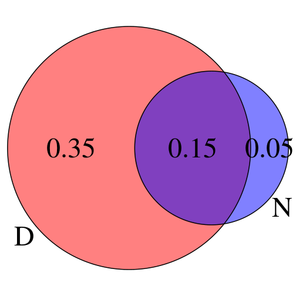

**Table**

```r
     |  D |not D|Tot.
-----|----|-----|----
N    | .15| .05 | .20
-----|----|-----|----
not N| .35| .45 | .80
-----|----|-----|----
Total| .50| .50 | 1
```

### Two-way probability table

**Table**

```r
     |  D |not D|Tot.
-----|----|-----|----
N    | .15| .05 | .20
-----|----|-----|----
not N| .35| .45 | .80
-----|----|-----|----
Total| .50| .50 | 1
```

What is the prob. of

- experiencing nausea or a decrease in sexual drive?
- experiencing only nausea?
- experiencing neither of these side effects?

### Motivating example

All the students in a certain high school were surveyed, then classified according to gender and whether they had either of their ears pierced:

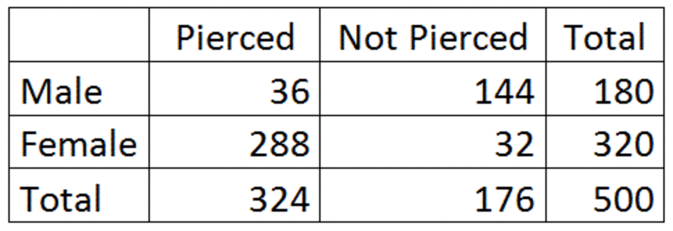

Let \( M \) denote the events of being male, and \( E \) denote the events of having pierced ears.

### Motivating example

Let \( M \) denote the events of being male, and \( E \) denote the events of having pierced ears.

What is the probability of **a student having pierced ears**?

\[ P(E) = 324/500 = .648 \]

implying that 64.8% of students have pierced ears.

### Motivating example

Let \( M \) denote the events of being male, and \( E \) denote the events of having pierced ears.

What is the probability that **a student is male**?

\[ P(M) = 180/500 = .36 \]

implying that 36% of students are male.

### Motivating example

Let \( M \) denote the events of being male, and \( E \) denote the events of having pierced ears.

What is the probability that **a male has pierced ears**?

New notation: \( P(E|M) \)

- the \( | \) stands for “given”
- **read as** the probability of event E given event M.
- **read as** the probability of event a student having pieced ears given that the student is male.
- **read as** the probability that a male student has pierced ears.

### Motivating example

What is the probability that **a male has pierced ears**?

\[ P(E|M) = 36/180 = 0.20 \]

More generally

\[ P(E|M) = \frac{P(E \text{ and } M)}{ P(M)} \]

### $$\text{Recall: } C \rightarrow C$$

Are men and women just as likely to think their weight is about right?

What are the response and explanatory variables?

**Reponse**: body image, **Explanatory:** gender

### Recall: Conditional distributions

What is the distribution of body image **conditional** on gender?

**Step 1:** Identify the conditioning variable. (gender)

**Step 2:** Calculate **conditional proportions** (or %)

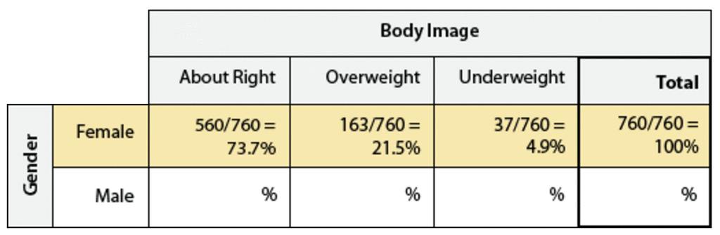

### Recall: Conditional distributions

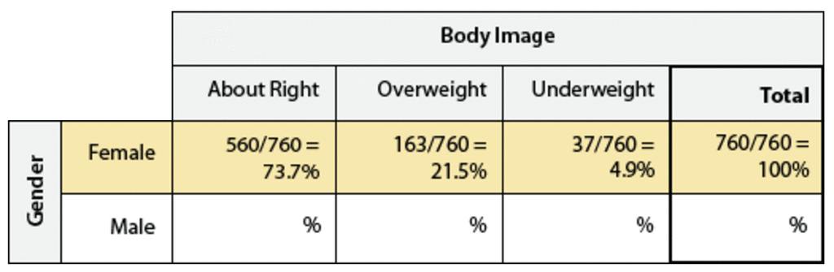

Let \( A \) be “About Right”, and similarly \( O \) “Overweight” and \( U \) “Underweight”.

\[ \begin{aligned} P( A | F) & = .737 & P( O | F) & = .215 \\ P( U | F) & = .049 \end{aligned} \]

### $$\text{Recall: } C \rightarrow C$$

What is the probability that

- a man feels his weight is about right?
- a person who feels their weight is about right is a man?

### $$\text{Recall: } C \rightarrow C$$

What is the probability that a man feels his weight is about right?

\( P(A|M) = \frac{P(A \text{ and } M)}{P(M)} = \frac{295/1200}{440/1200} = 295/440 = .67 \)

implying that about 67% of men feel their weight is about right.

### $$\text{Recall: } C \rightarrow C$$

What is the probability that a person who feels their weight is about right is a man?

\[ P(M|A) = 295/855 = .345 \]

implying that about 35% of people who feel their weight is about right are men.

### $$P(M|A) \ne P(A|M)$$

This is a **very** important distinction.

\[ P(A|M) = 295/440 = .67 \]

implying that about 67% of men feel their weight is about right.

\[ P(M|A) = 295/855 = .345 \]

implying that about 35% of people who feel their weight is about right are men.

### The choice of condition matters!

There have been 44 US presidents. All US presidents have been men.

Aproximately 100 billion people (i.e. 50 billion men) have ever lived ([source](http://en.wikipedia.org/wiki/World_population#Number_of_humans_who_have_ever_lived)).

- (a) What is the probability that a man is or was a US President?
  - \( P(P|M) = \frac{P(P \text{ and } M)}{P(M)} = \frac{44 / (100 \times 10^9) }{(50 \times 10^9) / (100 \times 10^9)} \approx 0 \)
- (b) What is the probability that a US President is or was a man?
  - \( P(M|P) = \frac{P(P \text{ and } M)}{P(P)} = \frac{44/ (100 \times 10^9)}{44/ (100 \times 10^9)} = 1 \)

### Independence and Cond. Prob.

Recall that if events \( A \) and \( B \) are independent, then

\[ P(A \text{ and } B ) = P(A) P(B) \]

Recall the definition of conditional probability:

\[ P(A|B) = \frac{P(A \text{ and } B )}{P(B)} \]

**If and only if** \( A \) is independent of \( B \), then

\[ P(A|B) = \frac{P(A \text{ and } B )}{P(B)} = \frac{P(A)P(B)}{P(B)} = P(A) \]

### Independence and Cond. Prob.

**Short**

\( A \) is **independent** of \( B \) if and only if \( P(A|B) = P(A) \)

**Long**

> Two events A and B are said to be independent if the fact that one event has occurred does not affect the probability that the other event will occur. If whether or not one event occurs does affect the probability that the other event will occur, then the two events are said to be dependent.

### Checking independence

All the students in a certain high school were surveyed, then classified according to gender and whether they had either of their ears pierced:

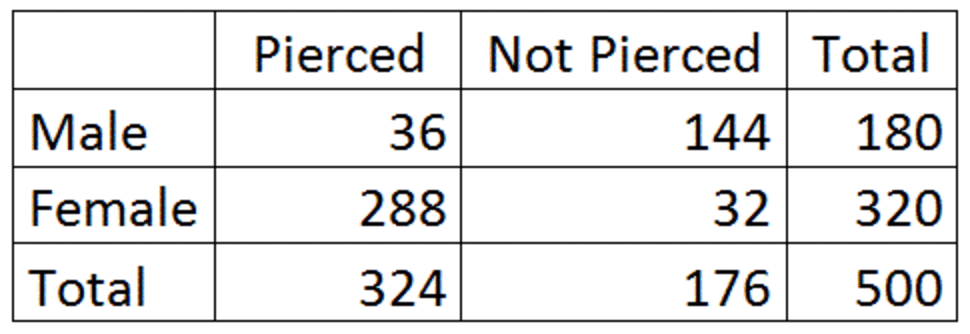

Are **gender** and **piercing** independent?

### Checking independence

Are **gender** and **piercing** independent?

If they are independent, **all** of the following will hold:

\[ \begin{aligned} P( P | M ) & = P(P) & P( P | F ) & = P(P) \\ P( M | P ) & = P(M) & P( F | P ) & = P(F) \\ P( P | F ) & = P( P | M) & P( M | P ) & = P( M | \text{ not } P) \end{aligned} \]

### Checking independence

Are **gender** and **piercing** independent?

Most direct: Check if \( P(P|F) = P(P|M) \)

\( P(P|F) = \frac{P(P \text{ and } F)}{P(F)} = \frac{288/500}{320/500} = .9 \)

\( P(P|M) = \frac{P(P \text{ and } M)}{P(M)} = \frac{36/500}{180/500} = .2 \)

### Bringing it all together

Are **gender** and **piercing** independent?

**No.** From the previous calculations, 90% of women have piercings \( \left( P(P|F) = .9 \right) \), while only 20% of men do \( \left(P(P|M) = .2\right) \). Since a person is much more likely to have piercings if they are female than if they are male, gender and piercing are **not** independent.

### Looking ahead

What if we had only looked at a single classroom?

- If we **only** sampled a classroom of 30 students
- where we found \( P(P|F) = .2 \) and \( P(P|M) = .25 \)
- could we still conclude that gender and piercing were independent?

**Answer will come after the midterm.**